# EBS Pollock RTMB Implementation

- Show All Code
- Hide All Code
- View Source

# 1 Overview

This document summarizes the RTMB implementation of the EBS pollock ADMB bridge model in this standalone source repository. It follows the same assessment-reporting framework used by the FIMS, SPoRC, and Rceattle implementation documents, but reads the RTMB report object written by `Rscript R/write_output.R`.

The current RTMB implementation should be interpreted as an ADMB-port bridge rather than a self-contained assessment package. It uses the dedicated ADMB bridge run in `admb/runs/for_rtmb/` for initialization and comparison. By default, this report reads the saved RTMB output at `analysis/output/base.rds`, which was created from the ADMB bridge `pm.rep` and `pm.par` files.

# 2 Data Inputs

The RTMB input series include annual fishery catch, fishery age compositions, BTS and ATS age compositions, BTS and ATS survey biomass or abundance indices, acoustic vessels of opportunity, and fishery CPUE. The input data and bridge ADMB output are resolved through `R/config.R` using the external pollock workspace supplied by `POLLOCK_ROOT`.

```r
summary_tbl <- tibble(
  item = c(
    "Years",
    "Ages",
    "Fishery age-composition years",
    "BTS index years",
    "ATS index years",
    "CPUE years",
    "AVO years",
    "Saved RTMB output"
  ),
  value = c(
    paste0(first_year, "-", terminal_year, " (", length(years), ")"),
    paste0(min(ages), "-", max(ages), " (", length(ages), ")"),
    paste0(min(data$yrs_fsh_data), "-", max(data$yrs_fsh_data), " (", length(data$yrs_fsh_data), ")"),
    paste0(min(data$yrs_bts_data), "-", max(data$yrs_bts_data), " (", length(data$yrs_bts_data), ")"),
    paste0(min(data$yrs_ats_data), "-", max(data$yrs_ats_data), " (", length(data$yrs_ats_data), ")"),
    paste0(min(data$yrs_cpue), "-", max(data$yrs_cpue), " (", length(data$yrs_cpue), ")"),
    paste0(min(data$yrs_avo), "-", max(data$yrs_avo), " (", length(data$yrs_avo), ")"),
    params$model_file
  )
)

summary_tbl |>
  gt_report() |>
  tab_header(title = "RTMB-ADMB Input Summary")
```

Table 1: Summary of the EBS pollock RTMB-ADMB input data.

RTMB-ADMB Input Summary

| item | value |
| --- | --- |
| Years | 1964-2024 (61) |
| Ages | 1-15 (15) |
| Fishery age-composition years | 1964-2023 (60) |
| BTS index years | 1982-2024 (42) |
| ATS index years | 1994-2024 (19) |
| CPUE years | 1965-1976 (12) |
| AVO years | 2006-2024 (18) |
| Saved RTMB output | analysis/output/base.rds |

```r
availability <- bind_rows(
  tibble(name = "Fishery", type = "catch", year = years),
  tibble(name = "Fishery", type = "age_comp", year = data$yrs_fsh_data),
  tibble(name = "BTS", type = "index", year = data$yrs_bts_data),
  tibble(name = "BTS", type = "age_comp", year = data$yrs_bts_data),
  tibble(name = "ATS", type = "index", year = data$yrs_ats_data),
  tibble(name = "ATS", type = "age_comp", year = data$yrs_ats_data),
  tibble(name = "CPUE", type = "index", year = data$yrs_cpue),
  tibble(name = "AVO", type = "index", year = data$yrs_avo)
) |>
  group_by(name, type) |>
  summarize(
    n_obs = n(),
    years = paste0(min(year, na.rm = TRUE), "-", max(year, na.rm = TRUE)),
    .groups = "drop"
  ) |>
  arrange(type, name)

availability |>
  gt_report() |>
  tab_header(title = "Data Availability by Fleet")
```

Table 2: Available observations by fleet and data type.

Data Availability by Fleet

| name | type | n_obs | years |
| --- | --- | --- | --- |
| ATS | age_comp | 19 | 1994-2024 |
| BTS | age_comp | 42 | 1982-2024 |
| Fishery | age_comp | 60 | 1964-2023 |
| Fishery | catch | 61 | 1964-2024 |
| ATS | index | 19 | 1994-2024 |
| AVO | index | 18 | 2006-2024 |
| BTS | index | 42 | 1982-2024 |
| CPUE | index | 12 | 1965-1976 |

```r
bridge_file_paths <- c(rtmb_metadata$admb_rep, rtmb_metadata$admb_par, pollock_file("admb", "runs", "for_rtmb", "pm.tpl"))
bridge_files <- tibble(
  file = display_path(bridge_file_paths),
  role = c("ADMB report used for comparison", "ADMB parameter file used for initialization", "ADMB bridge template"),
  exists = file.exists(bridge_file_paths),
  size_kb = round(file.info(bridge_file_paths)$size / 1024, 1),
  modified = as.POSIXct(file.info(bridge_file_paths)$mtime)
)

bridge_files |>
  gt_report() |>
  fmt_number(columns = size_kb, decimals = 1) |>
  tab_header(title = "ADMB Bridge Files")
```

Table 3: ADMB bridge files used by the RTMB implementation.

ADMB Bridge Files

| file | role | exists | size_kb | modified |
| --- | --- | --- | --- | --- |
| [pollock]/admb/runs/for_rtmb/pm.rep | ADMB report used for comparison | TRUE | 157.6 | 2025-09-02 12:31:31.589708 |
| [pollock]/admb/runs/for_rtmb/pm.par | ADMB parameter file used for initialization | TRUE | 32.0 | 2025-09-02 12:31:20.087954 |
| [pollock]/admb/runs/for_rtmb/pm.tpl | ADMB bridge template | TRUE | 279.3 | 2025-09-02 11:58:35.84933 |

# 3 Model Implementation

## 3.1 Structure

- **Population**: single EBS pollock stock.
- **Model engine**: RTMB with the negative log-likelihood written in R.
- **Reference model**: ADMB bridge run in `admb/runs/for_rtmb/`.
- **Fleets and indices**: fishery catch, fishery CPUE, BTS, ATS, and AVO.
- **Age compositions**: fishery, BTS, and ATS age-composition likelihoods.
- **Recruitment**: ADMB-port recruitment likelihood and deviations.
- **Natural mortality**: age-specific input vector from the ADMB bridge data.
- **Selectivity**: fishery, BTS, and ATS selectivity blocks ported from the ADMB bridge configuration.

## 3.2 BTS Selectivity Variation and Penalties

The bottom trawl survey (BTS) selectivity in the RTMB bridge is represented as a time-varying logistic curve for ages 2 and older, with a separate age-1 term. For BTS year (t) and model age (a), the code uses the age midpoint (x_a = a + 0.5) and computes

$$\log s_{t,a}^{\mathrm{BTS}}
= -\log\left[
1 + \exp\left\{-\exp(\gamma_t)\left(x_a - \exp(\alpha_t)\right)\right\}
\right],$$

where $\gamma_t$ is the annual log-slope parameter (`sel_slp_bts_dev`) and $\alpha_t$ is the annual log-age-at-50% parameter (`sel_a50_bts_dev`). Thus the realized slope is $\exp(\gamma_t)$, and the realized age-at-50% is $\exp(\alpha_t)$. Age 1 is then overwritten by its own annual log-selectivity term:

$$\log s_{t,1}^{\mathrm{BTS}} = \eta_t,$$

where $\eta_t$ is `sel_age_one_bts_dev`.

The current RTMB call treats `sel_slp_bts_dev`, `sel_a50_bts_dev`, and `sel_age_one_bts_dev` as estimated annual vectors. The base logistic BTS terms `sel_slp_bts`, `sel_a50_bts`, `sel_age_one_bts`, and `sel_devs_bts` are fixed in `R/config.R`; the time variation is carried by the annual deviation vectors above.

The regularization is applied to the implied annual log-selectivity curves, not directly to $\alpha_t$ or $\gamma_t$. In `selectivity_like_bts()`, an extended matrix $\tilde{\ell}_{t,a}$ is formed by prepending a zero row for the year before the BTS time series. Let $\Delta_t z_t = z_t - z_{t-1}$. The BTS time-variation penalty for ages $a = q_{\min}, \ldots, q_{\max}-1$ is

$$P_{\mathrm{BTS,time}}
= \lambda_{\mathrm{BTS}}
\sum_{a=q_{\min}}^{q_{\max}-1}
\sum_t
\left(\Delta_t \tilde{\ell}_{t,a}\right)^2,$$

where $\lambda_{\mathrm{BTS}}$ is `selVarbts`. In this configuration, `q_amin = 3`, `q_amax` defaults to `nages`, and `nages = 15`, so this penalty applies to ages 3 through 14. Age 2 is not included in this time-smoothness sum, and age 15 is not directly included because the loop stops at `q_amax - 1`.

The age-1 BTS term has a separate first-difference penalty:

$$P_{\mathrm{BTS,age1}}
= 8
\sum_t
\left[
\Delta_t\left(\eta_t - \bar{\eta}\right)
\right]^2,$$

where $\bar{\eta}$ is the mean of the age-1 deviation vector. The total BTS selectivity regularization returned by `selectivity_like_bts()` is

$$P_{\mathrm{BTS}}
= P_{\mathrm{BTS,time}} + P_{\mathrm{BTS,age1}},$$

with no additional BTS curvature penalty active under the current logistic-deviation parameterization.

```r
bts_sel_tbl <- tibble(
  item = c(
    "BTS selectivity start year",
    "Terminal year",
    "Number of annual BTS selectivity years",
    "Estimated annual slope vector",
    "Estimated annual age-at-50 vector",
    "Estimated annual age-1 vector",
    "Time-smoothness weight (`selVarbts`)",
    "Time-smoothness age range",
    "Age-1 first-difference weight",
    "Inactive base BTS terms fixed in config"
  ),
  value = c(
    as.character(data$styr_bts),
    as.character(data$endyr),
    as.character(data$endyr - data$styr_bts + 1),
    "sel_slp_bts_dev",
    "sel_a50_bts_dev",
    "sel_age_one_bts_dev",
    as.character(data$selVarbts),
    paste0(data$q_amin, "-", data$nages - 1),
    "8",
    "sel_devs_bts, sel_slp_bts, sel_a50_bts, sel_age_one_bts"
  )
)

bts_sel_tbl |>
  gt_report() |>
  tab_header(title = "BTS Selectivity Regularization")
```

Table 4: BTS selectivity variation and regularization settings in the current RTMB-ADMB configuration.

BTS Selectivity Regularization

| item | value |
| --- | --- |
| BTS selectivity start year | 1982 |
| Terminal year | 2024 |
| Number of annual BTS selectivity years | 43 |
| Estimated annual slope vector | sel_slp_bts_dev |
| Estimated annual age-at-50 vector | sel_a50_bts_dev |
| Estimated annual age-1 vector | sel_age_one_bts_dev |
| Time-smoothness weight (`selVarbts`) | 2 |
| Time-smoothness age range | 3-14 |
| Age-1 first-difference weight | 8 |
| Inactive base BTS terms fixed in config | sel_devs_bts, sel_slp_bts, sel_a50_bts, sel_age_one_bts |

## 3.3 Run Definitions

The current report has one saved RTMB run, `base`, written by `R/write_output.R`. Refitting can be enabled at render time with `params$refit: true`, but the default render reads the saved RTMB report object to avoid rerunning the optimizer.

```r
run_tbl <- tibble(
  run = "base",
  source = params$model_file,
  refit_default = params$refit,
  output_available = file.exists(model_file),
  report_elements = length(names(rtmb_report)),
  created = as.character(rtmb_metadata$created %||% NA_character_)
)

run_tbl |>
  gt_report() |>
  tab_header(title = "RTMB-ADMB Run Definitions")
```

Table 5: Configured RTMB-ADMB run definitions.

RTMB-ADMB Run Definitions

| run | source | refit_default | output_available | report_elements | created |
| --- | --- | --- | --- | --- | --- |
| base | analysis/output/base.rds | FALSE | TRUE | 42 | 2026-05-07 12:14:58.680596 |

The base output writer follows this pattern.

**Show RTMB output-generation call**

```r
source("R/config.R")
data$return_nll_only <- 0
rtmb_result <- rpm(parms)
saveRDS(
  list(report = rtmb_result$rtmb, metadata = list(model = "rtmb_ebswp")),
  "analysis/output/base.rds"
)
```

# 4 Results

## 4.1 Fit to Base RTMB-ADMB Run

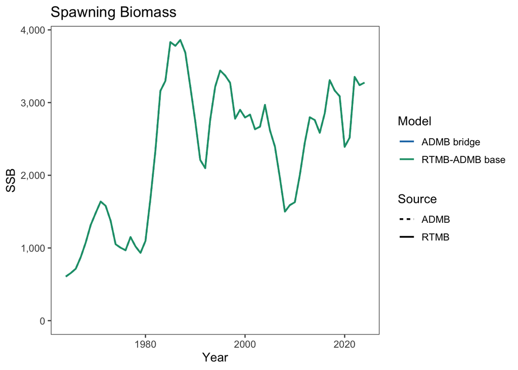

Figure 1: Estimated spawning biomass from the saved EBS pollock RTMB-ADMB base model, with the ADMB bridge output overlaid when available.

```r
ssb_overlay <- bind_rows(
  ts_df |>
    transmute(model = "RTMB-ADMB base", source = "RTMB", year, value = ssb),
  admb_ts |>
    filter(quantity == "SSB") |>
    transmute(model, source, year, value)
)

ggplot(ssb_overlay, aes(x = year, y = value, color = model, linetype = source)) +
  geom_line(linewidth = 0.8) +
  scale_y_continuous(limits = c(0, NA), labels = scales::label_comma()) +
  scale_color_manual(values = c("RTMB-ADMB base" = "#1b9e77", "ADMB bridge" = "#1f78b4")) +
  scale_linetype_manual(values = c("RTMB" = "solid", "ADMB" = "22")) +
  labs(x = "Year", y = "SSB", color = "Model", linetype = "Source", title = "Spawning Biomass")
```

### 4.1.1 Catch Fit

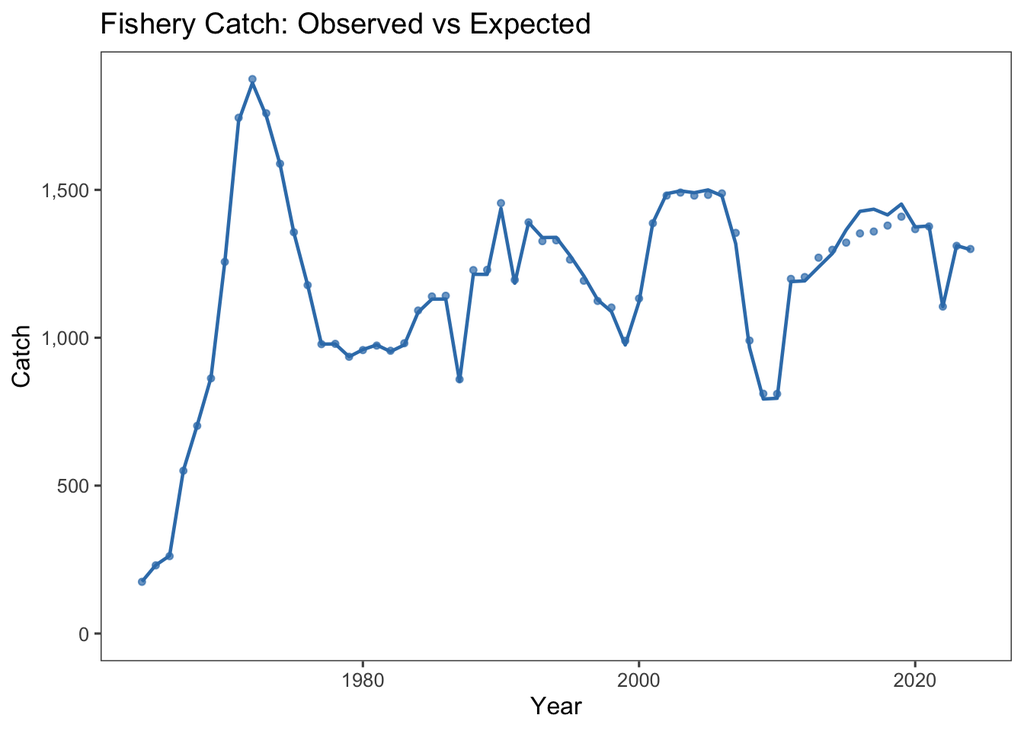

Figure 2: Observed fishery catch and predicted catch from the saved RTMB-ADMB model.

```r
ggplot(catch_df, aes(x = year)) +
  geom_line(aes(y = expected), color = "#377eb8", linewidth = 0.8) +
  geom_point(aes(y = observed), color = "#377eb8", size = 1.2, alpha = 0.7) +
  scale_y_continuous(limits = c(0, NA), labels = scales::label_comma()) +
  labs(x = "Year", y = "Catch", title = "Fishery Catch: Observed vs Expected")
```

### 4.1.2 Fits by Fleet

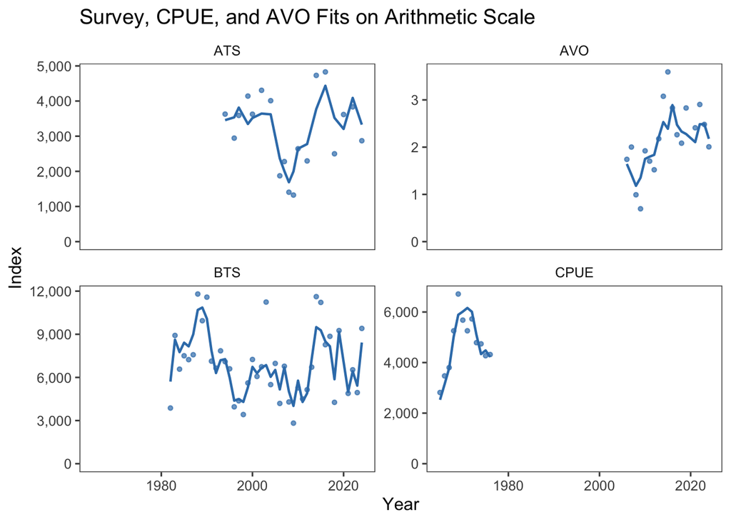

Figure 3: Observed and predicted index series from the saved RTMB-ADMB model, shown on arithmetic scales with separate facet axes.

```r
ggplot(index_df, aes(x = year)) +
  geom_line(aes(y = expected), color = "#377eb8", linewidth = 0.8) +
  geom_point(aes(y = observed), color = "#377eb8", size = 1.1, alpha = 0.7, na.rm = TRUE) +
  facet_wrap(~series, scales = "free_y") +
  scale_y_continuous(limits = c(0, NA), labels = scales::label_comma()) +
  labs(x = "Year", y = "Index", title = "Survey, CPUE, and AVO Fits on Arithmetic Scale")
```

### 4.1.3 Residuals

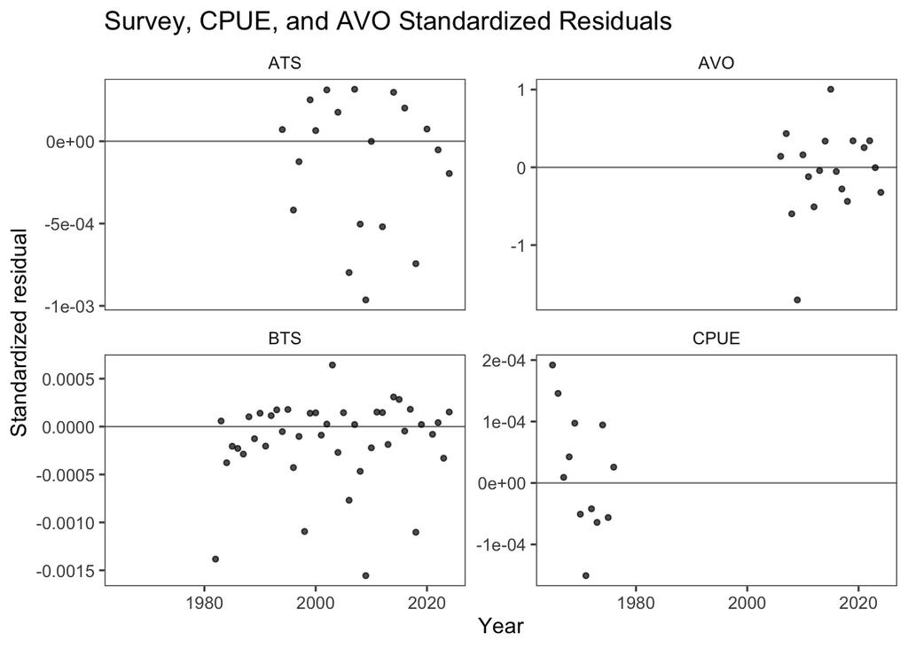

Figure 4: Approximate standardized log residuals for RTMB-ADMB index observations. Residuals are divided by the input log standard deviation.

```r
ggplot(index_df, aes(x = year, y = std_residual)) +
  geom_hline(yintercept = 0, color = "gray50", linewidth = 0.4) +
  geom_point(size = 1.1, alpha = 0.7) +
  facet_wrap(~series, scales = "free_y") +
  labs(x = "Year", y = "Standardized residual", title = "Survey, CPUE, and AVO Standardized Residuals")
```

### 4.1.4 Age Composition Fits

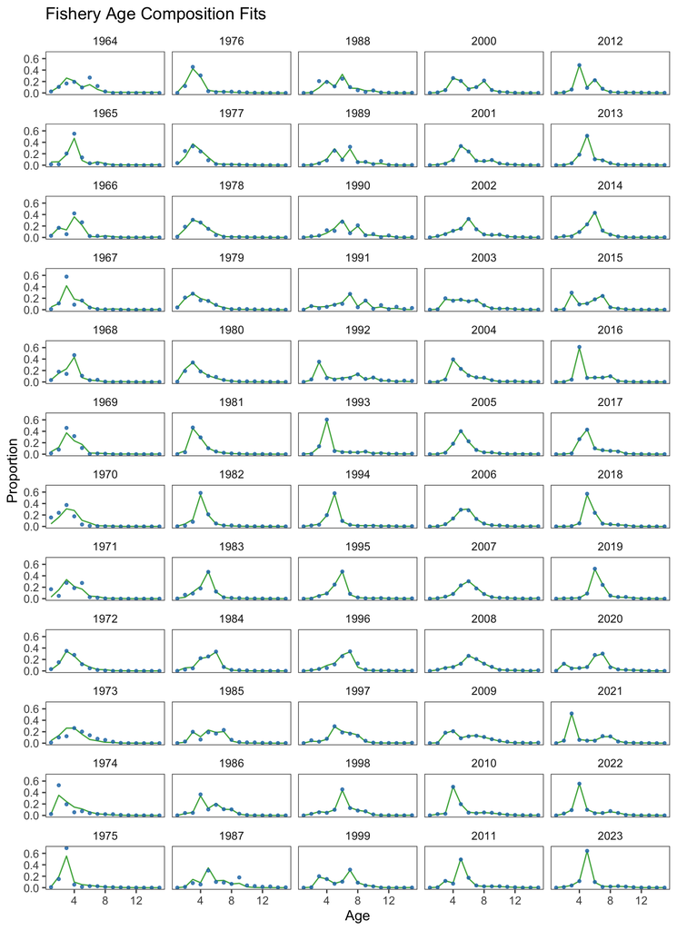

Figure 5: Observed and expected fishery age-composition patterns from the saved RTMB-ADMB model, faceted by year.

```r
plot_agecomp_fit(agecomp_df, "Fishery", ncol = 5)
```

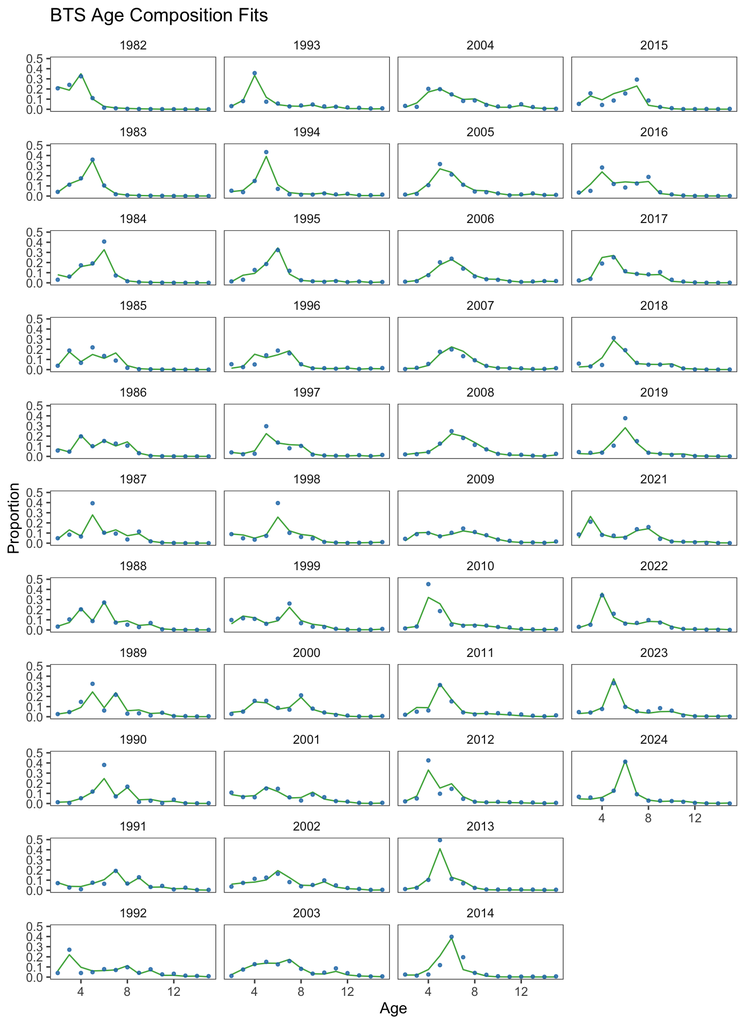

Figure 6: Observed and expected BTS age-composition patterns from the saved RTMB-ADMB model, faceted by year.

```r
plot_agecomp_fit(agecomp_df, "BTS", ncol = 4)
```

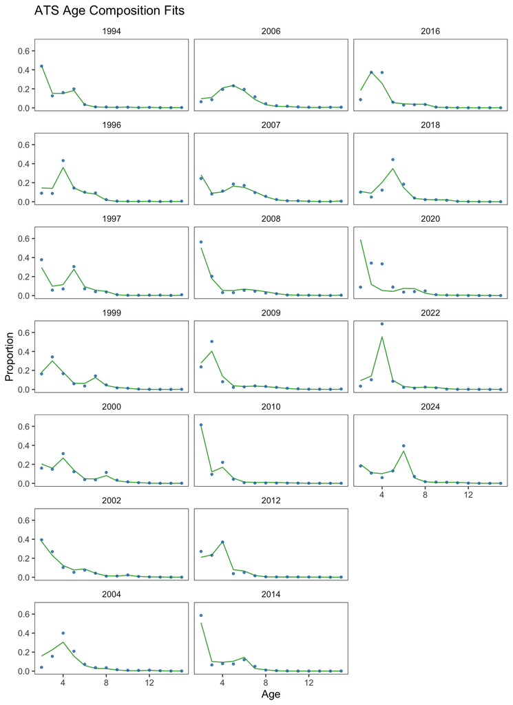

Figure 7: Observed and expected ATS age-composition patterns from the saved RTMB-ADMB model, faceted by year.

```r
plot_agecomp_fit(agecomp_df, "ATS", ncol = 3)
```

### 4.1.5 OSA Residual Diagnostics

The report now uses saved `afscOSA::run_osa()` output when available, generated under R 4.6 from the current RTMB composition inputs. In this render, the residual method is Pearson residual fallback for composition data. When saved OSA output is unavailable, the same chunks fall back to the workspace helper `R/plot_osa_comps.R` if its dependencies are available, then to Pearson residual bubble diagnostics.

```r
tibble(
  item = c(
    "Saved OSA output",
    "OSA R version",
    "Helper sourceable",
    "afscOSA installed in render R",
    "resMulti loaded",
    "Residual method",
    "Fleets",
    "Residual rows"
  ),
  value = c(
    as.character(osa_precomputed_available),
    if (isTRUE(osa_precomputed_available)) osa_output$r_version else NA_character_,
    as.character(osa_helper_loaded),
    as.character(requireNamespace("afscOSA", quietly = TRUE)),
    as.character(osa_res_multi_loaded),
    osa_residual_method,
    paste(sort(unique(diagnostic_residual_df$fleet)), collapse = ", "),
    as.character(nrow(diagnostic_residual_df))
  )
) |>
  gt_report() |>
  tab_header(title = "OSA Residual Diagnostic Status")
```

Table 6: Composition residual diagnostic status for the RTMB-ADMB report.

OSA Residual Diagnostic Status

| item | value |
| --- | --- |
| Saved OSA output | FALSE |
| OSA R version | NA |
| Helper sourceable | TRUE |
| afscOSA installed in render R | FALSE |
| resMulti loaded | FALSE |
| Residual method | Pearson residual fallback for composition data |
| Fleets | ATS, BTS, Fishery |
| Residual rows | 1754 |

```r
diagnostic_sdnr_df |>
  arrange(fleet) |>
  select(
    Fleet = fleet,
    `Residual rows` = n,
    `Mean residual` = mean_residual,
    SDNR = sdnr,
    `Minimum residual` = min_residual,
    `Maximum residual` = max_residual,
    `|residual| > 3` = outliers_abs_gt_3
  ) |>
  gt_report() |>
  fmt_number(
    columns = c(`Mean residual`, SDNR, `Minimum residual`, `Maximum residual`),
    decimals = 3
  ) |>
  fmt_number(columns = c(`Residual rows`, `|residual| > 3`), decimals = 0) |>
  tab_header(title = "OSA Residual SDNR Summary")
```

Table 7: Summary statistics for RTMB-ADMB composition residual diagnostics. SDNR is the standard deviation of normalized residuals by fleet.

OSA Residual SDNR Summary

| Fleet | Residual rows | Mean residual | SDNR | Minimum residual | Maximum residual | \|residual\| > 3 |
| --- | --- | --- | --- | --- | --- | --- |
| ATS | 266 | 0.004 | 0.475 | −2.135 | 1.770 | 0 |
| BTS | 588 | 0.092 | 0.824 | −3.891 | 5.089 | 3 |
| Fishery | 900 | 0.073 | 0.748 | −2.002 | 10.316 | 4 |

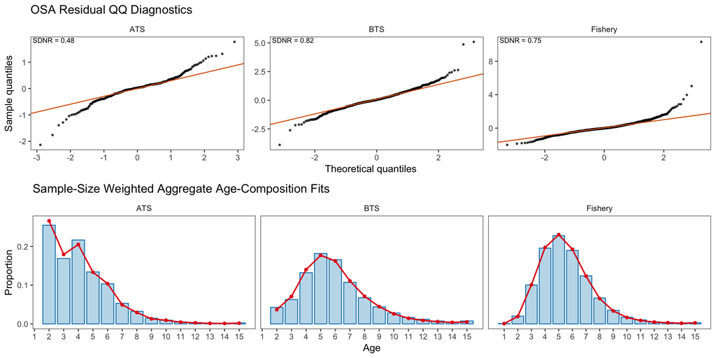

```r
plot_osa_aggregate_panel(
  residual_data = diagnostic_residual_df,
  aggregate_data = weighted_aggregate_agecomp_df,
  osa_output = osa_output
)
```

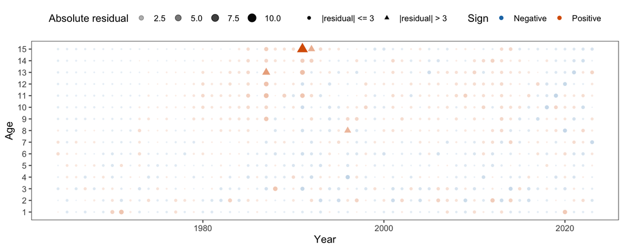

Figure 9: Composition residual diagnostics for the fishery age-composition fit. Saved afscOSA OSA residuals are used when available; otherwise the report falls back to Pearson residual bubbles.

```r
plot_osa_comps_for_fleet("Fishery")
```

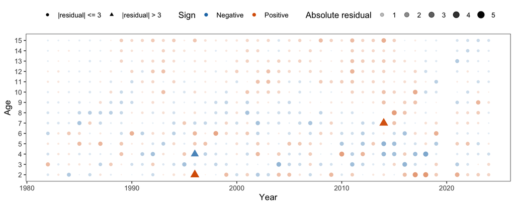

Figure 10: Composition residual diagnostics for the BTS age-composition fit. Saved afscOSA OSA residuals are used when available; otherwise the report falls back to Pearson residual bubbles.

```r
plot_osa_comps_for_fleet("BTS")
```

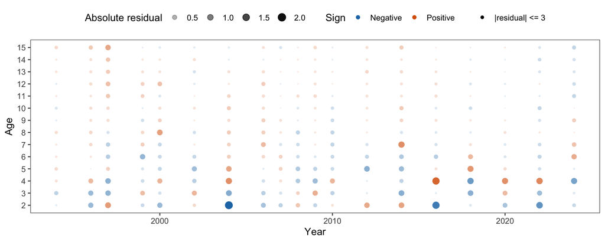

Figure 11: Composition residual diagnostics for the ATS age-composition fit. Saved afscOSA OSA residuals are used when available; otherwise the report falls back to Pearson residual bubbles.

```r
plot_osa_comps_for_fleet("ATS")
```

### 4.1.6 Selectivity Curves

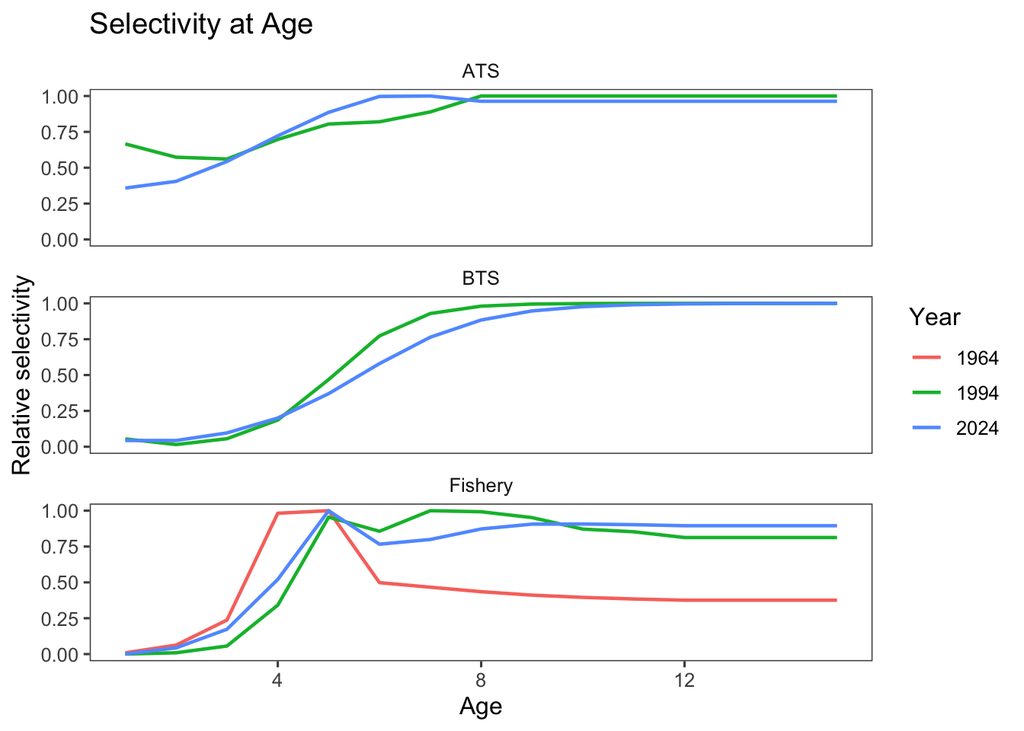

Figure 12: Estimated RTMB-ADMB selectivity-at-age curves by fleet in selected years.

```r
selected_years <- c(first_year, years[ceiling(length(years) / 2)], terminal_year)
sel_df <- bind_rows(
  as_year_age_df(rtmb_report$sel_fsh, years, "Fishery", "selectivity"),
  as_year_age_df(rtmb_report$sel_bts, data$styr_bts:data$endyr, "BTS", "selectivity"),
  as_year_age_df(rtmb_report$sel_ats, data$styr_ats:data$endyr, "ATS", "selectivity")
) |>
  filter(year %in% selected_years | year == min(year) | year == max(year)) |>
  group_by(fleet, year) |>
  mutate(selectivity = selectivity / max(selectivity, na.rm = TRUE)) |>
  ungroup()

ggplot(sel_df, aes(x = age, y = selectivity, color = factor(year))) +
  geom_line(linewidth = 0.8) +
  facet_wrap(~fleet, ncol = 1) +
  scale_y_continuous(limits = c(0, NA)) +
  labs(x = "Age", y = "Relative selectivity", color = "Year", title = "Selectivity at Age")
```

### 4.1.7 Selectivity Ridge Plots

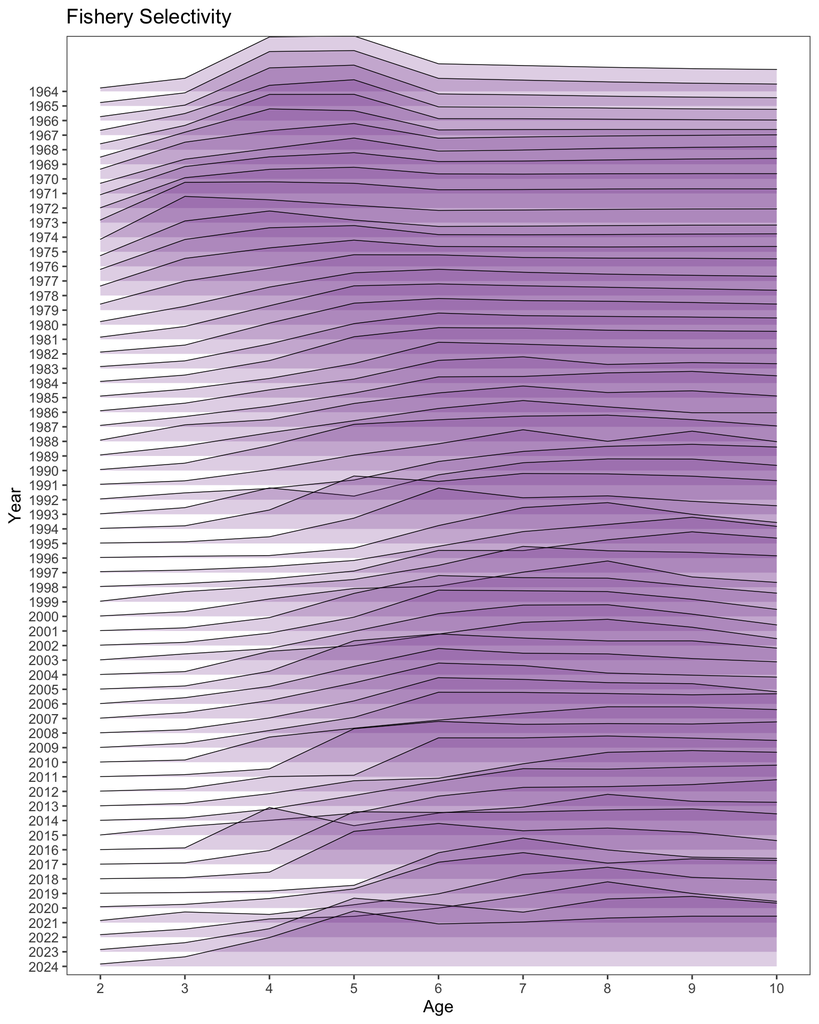

Figure 13: Relative fishery selectivity over time from the RTMB-ADMB model. Ridge heights are normalized within year.

```r
ridge_df <- bind_rows(
  as_year_age_df(rtmb_report$sel_fsh, years, "Fishery", "selectivity"),
  as_year_age_df(rtmb_report$sel_bts, data$styr_bts:data$endyr, "BTS", "selectivity"),
  as_year_age_df(rtmb_report$sel_ats, data$styr_ats:data$endyr, "ATS", "selectivity")
) |>
  filter(age >= 2, age <= 10) |>
  group_by(fleet, year) |>
  mutate(relative_selectivity = selectivity / max(selectivity, na.rm = TRUE)) |>
  ungroup() |>
  mutate(year_factor = factor(year, levels = rev(sort(unique(year)))))

ggplot(ridge_df |> filter(fleet == "Fishery"), aes(x = age, y = year_factor, height = relative_selectivity)) +
  ggridges::geom_density_ridges(
    stat = "identity",
    scale = 3.8,
    alpha = 0.22,
    fill = "#7b3294",
    color = "black",
    linewidth = 0.25
  ) +
  scale_x_continuous(limits = c(2, 10), breaks = 2:10) +
  labs(x = "Age", y = "Year", title = "Fishery Selectivity")
```

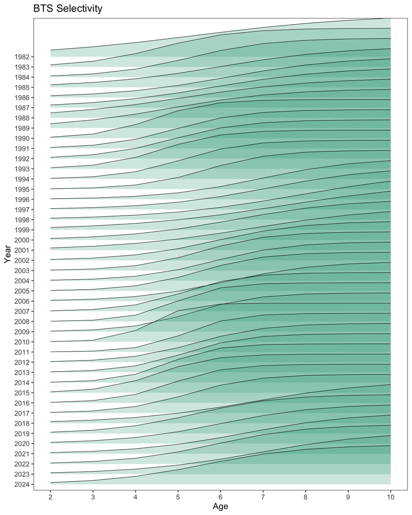

Figure 14: Relative BTS selectivity over time from the RTMB-ADMB model. Ridge heights are normalized within year.

```r
ggplot(ridge_df |> filter(fleet == "BTS"), aes(x = age, y = year_factor, height = relative_selectivity)) +
  ggridges::geom_density_ridges(
    stat = "identity",
    scale = 3.8,
    alpha = 0.22,
    fill = "#1b9e77",
    color = "black",
    linewidth = 0.25
  ) +
  scale_x_continuous(limits = c(2, 10), breaks = 2:10) +
  labs(x = "Age", y = "Year", title = "BTS Selectivity")
```

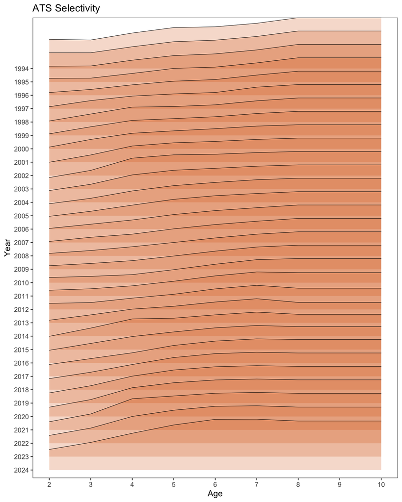

Figure 15: Relative ATS selectivity over time from the RTMB-ADMB model. Ridge heights are normalized within year.

```r
ggplot(ridge_df |> filter(fleet == "ATS"), aes(x = age, y = year_factor, height = relative_selectivity)) +
  ggridges::geom_density_ridges(
    stat = "identity",
    scale = 3.8,
    alpha = 0.22,
    fill = "#d95f02",
    color = "black",
    linewidth = 0.25
  ) +
  scale_x_continuous(limits = c(2, 10), breaks = 2:10) +
  labs(x = "Age", y = "Year", title = "ATS Selectivity")
```

# 5 Projections

The RTMB bridge can now write a Standard Projection Model input directory for use with `spmR`. This report writes the current saved RTMB output to [repo]/analysis/output/spmR_projection, using the same SPM setup structure as the ADMB bridge projection directory while replacing the species assessment input file with an RTMB-derived `pm.prj`.

```r
spmr_manifest |>
  mutate(
    file = basename(file),
    exists = as.character(exists)
  ) |>
  gt_report() |>
  tab_header(title = "spmR Projection Input Files")
```

Table 8: Projection input files written for the spmR/SPM workflow.

spmR Projection Input Files

| file | role | exists |
| --- | --- | --- |
| spm.dat | SPM setup file | TRUE |
| pm.prj | Species assessment input file generated from RTMB | TRUE |
| tacpar.dat | SPM TAC parameter file copied from ADMB bridge projection directory | TRUE |
| spm | SPM executable copied from ADMB bridge projection directory | TRUE |

```r
if (!is.null(spmr_input)) {
  tibble(
    item = c(
      "Projection directory",
      "Projection begin year",
      "Projection years",
      "Simulations",
      "Alternatives",
      "Species input file"
    ),
    value = c(
      display_path(spmr_projection$output_dir),
      as.character(spmr_input$beg_yr %||% spmr_input$styr),
      as.character(spmr_input$nprj_yrs %||% spmr_input$npro),
      as.character(spmr_input$nsims),
      paste(as.integer(spmr_input$alts %||% spmr_input$alt_list), collapse = ", "),
      as.character(spmr_input$datafile %||% spmr_input$spp_file_name)
    )
  ) |>
    gt_report() |>
    tab_header(title = "Generated SPM Setup")
} else {
  tibble(
    item = c("Projection directory", "spmR parser"),
    value = c(display_path(spmr_projection$output_dir), "spmR is not installed in the render environment")
  ) |>
    gt_report() |>
    tab_header(title = "Generated SPM Setup")
}
```

Table 9: Key settings in the generated SPM projection setup file.

Generated SPM Setup

| item | value |
| --- | --- |
| Projection directory | [repo]/analysis/output/spmR_projection |
| spmR parser | spmR is not installed in the render environment |

```r
spmr_alt_desc <- tibble(
  Alternative = 1:7,
  Name = c(
    "Maximum permissible ABC",
    "Author-specified ABC",
    "Average recent F",
    "Alternative SPR rate",
    "No fishing",
    "OFL threshold determination",
    "Status-determination ramp"
  ),
  Description = c(
    "Projects catch using the maximum permissible Tier 3 ABC harvest rate from the SPM harvest-control rule.",
    "Projects catch using the author-specified adjustment to the Tier 3 ABC harvest rate. In this generated RTMB setup, the author-F adjustment and ABC multiplier are both 1.0, so this alternative is currently equivalent to Alternative 1 unless those inputs are changed.",
    "Projects catch using the recent average fishing mortality read from the assessment input file, rather than recalculating catch from the ABC harvest-control rule.",
    "Projects catch using the user-specified Alternative 4 SPR rate. The generated setup uses SPR = 0.60, matching the SPM input convention for this alternative.",
    "Projects the stock forward with F = 0, so catch is zero after any fixed catch years specified in the setup file.",
    "Projects catch at the OFL harvest rate. This alternative is used for threshold/status-determination calculations and is not constrained by the TAC-equals-ABC rule in the same way as the ABC alternatives.",
    "Applies maximum permissible ABC catch for the first three projection years in the SPM implementation, then switches to the OFL harvest-rate calculation used for status determination."
  )
)

spmr_alt_desc |>
  gt_report() |>
  tab_header(title = "SPM Projection Alternatives")
```

Table 10: Text descriptions of the SPM projection alternatives included in the generated setup file.

SPM Projection Alternatives

| Alternative | Name | Description |
| --- | --- | --- |
| 1 | Maximum permissible ABC | Projects catch using the maximum permissible Tier 3 ABC harvest rate from the SPM harvest-control rule. |
| 2 | Author-specified ABC | Projects catch using the author-specified adjustment to the Tier 3 ABC harvest rate. In this generated RTMB setup, the author-F adjustment and ABC multiplier are both 1.0, so this alternative is curre… |
| 3 | Average recent F | Projects catch using the recent average fishing mortality read from the assessment input file, rather than recalculating catch from the ABC harvest-control rule. |
| 4 | Alternative SPR rate | Projects catch using the user-specified Alternative 4 SPR rate. The generated setup uses SPR = 0.60, matching the SPM input convention for this alternative. |
| 5 | No fishing | Projects the stock forward with F = 0, so catch is zero after any fixed catch years specified in the setup file. |
| 6 | OFL threshold determination | Projects catch at the OFL harvest rate. This alternative is used for threshold/status-determination calculations and is not constrained by the TAC-equals-ABC rule in the same way as the ABC alternativ… |
| 7 | Status-determination ramp | Applies maximum permissible ABC catch for the first three projection years in the SPM implementation, then switches to the OFL harvest-rate calculation used for status determination. |

```r
projection_age_schedules <- tibble(
  Age = ages,
  `Spawning wt-at-age` = as.numeric(data$wt_ssb[length(years), ]),
  `Fishery wt-at-age` = as.numeric(data$wt_fut %||% data$wt_fsh[length(years), ]),
  Maturity = as.numeric(data$p_mature / max(data$p_mature, na.rm = TRUE)),
  Selectivity = as.numeric(rtmb_report$sel_fsh[length(years), ])
)

projection_age_schedules |>
  gt_report() |>
  fmt_number(
    columns = c(`Spawning wt-at-age`, `Fishery wt-at-age`, Maturity, Selectivity),
    decimals = 3
  ) |>
  tab_header(title = "Projection Age-Specific Schedules")
```

Table 11: Key age-specific schedules used in the generated SPM projection input files.

Projection Age-Specific Schedules

| Age | Spawning wt-at-age | Fishery wt-at-age | Maturity | Selectivity |
| --- | --- | --- | --- | --- |
| 1 | 0.085 | 0.025 | 0.000 | 0.000 |
| 2 | 0.196 | 0.186 | 0.008 | 0.062 |
| 3 | 0.322 | 0.401 | 0.289 | 0.248 |
| 4 | 0.534 | 0.667 | 0.641 | 0.746 |
| 5 | 0.621 | 0.663 | 0.842 | 1.432 |
| 6 | 0.707 | 0.720 | 0.901 | 1.098 |
| 7 | 0.822 | 0.791 | 0.947 | 1.145 |
| 8 | 0.946 | 0.905 | 0.963 | 1.250 |
| 9 | 1.051 | 1.009 | 0.970 | 1.298 |
| 10 | 1.113 | 1.061 | 1.000 | 1.299 |
| 11 | 1.178 | 1.138 | 1.000 | 1.293 |
| 12 | 1.290 | 1.257 | 1.000 | 1.282 |
| 13 | 1.332 | 1.267 | 1.000 | 1.282 |
| 14 | 1.367 | 1.290 | 1.000 | 1.282 |
| 15 | 1.415 | 1.368 | 1.000 | 1.282 |